# R Programming: Take Home MidTerm

Denis Vrdoljak

Dec 4, 2019

PART 1

1.1. Load the titanic.csv data

```r
data <- read.csv("titanic.csv")
head(data)
```

```
##   PassengerId Survived Pclass
## 1           1        0      3
## 2           2        1      1
## 3           3        1      3
## 4           4        1      1
## 5           5        0      3
## 6           6        0      3
##                                                  Name    Sex Age SibSp Parch
## 1                             Braund, Mr. Owen Harris   male  22     1     0
## 2 Cumings, Mrs. John Bradley (Florence Briggs Thayer) female  38     1     0
## 3                              Heikkinen, Miss. Laina female  26     0     0
## 4        Futrelle, Mrs. Jacques Heath (Lily May Peel) female  35     1     0
## 5                            Allen, Mr. William Henry   male  35     0     0
## 6                                    Moran, Mr. James   male  NA     0     0
##             Ticket    Fare Cabin Embarked
## 1        A/5 21171  7.2500              S
## 2         PC 17599 71.2833   C85        C
## 3 STON/O2. 3101282  7.9250              S
## 4           113803 53.1000  C123        S
## 5           373450  8.0500              S
## 6           330877  8.4583              Q
```

1.2. Get rid of the following columns: ‘Name’, ‘Ticket’, ‘PassengerId’, ‘Cabin’

```r
data$Name <- NULL
data$Ticket <- NULL
data$PassengerId <- NULL
data$Cabin <- NULL

head(data)
```

```
##   Survived Pclass    Sex Age SibSp Parch    Fare Embarked
## 1        0      3   male  22     1     0  7.2500        S
## 2        1      1 female  38     1     0 71.2833        C
## 3        1      3 female  26     0     0  7.9250        S
## 4        1      1 female  35     1     0 53.1000        S
## 5        0      3   male  35     0     0  8.0500        S
## 6        0      3   male  NA     0     0  8.4583        Q
```

1.3. Replace the ‘Sex column with a binary column for whether the passenger is ‘Male’

```r
#Male is 1 and female is 0
levels(data$Sex) <- c(0,1)

head(data)
```

```
##   Survived Pclass Sex Age SibSp Parch    Fare Embarked
## 1        0      3   1  22     1     0  7.2500        S
## 2        1      1   0  38     1     0 71.2833        C
## 3        1      3   0  26     0     0  7.9250        S
## 4        1      1   0  35     1     0 53.1000        S
## 5        0      3   1  35     0     0  8.0500        S
## 6        0      3   1  NA     0     0  8.4583        Q
```

1.4. Show how many NA’s are in each column

```r
na_counts <- colSums(is.na(data))
na_counts
```

```
## Survived   Pclass      Sex      Age    SibSp    Parch     Fare Embarked
##        0        0        0      177        0        0        0        0
```

1.5. Which Column has the most NA’s? How many does it have?

```r
print("Column with the most NA's")
```

```
## [1] "Column with the most NA's"
```

```r
max_na<- subset(na_counts,na_counts==(max(na_counts)))
max_na
```

```
## Age
## 177
```

1.6. Create a bar chart to show NA counts by column

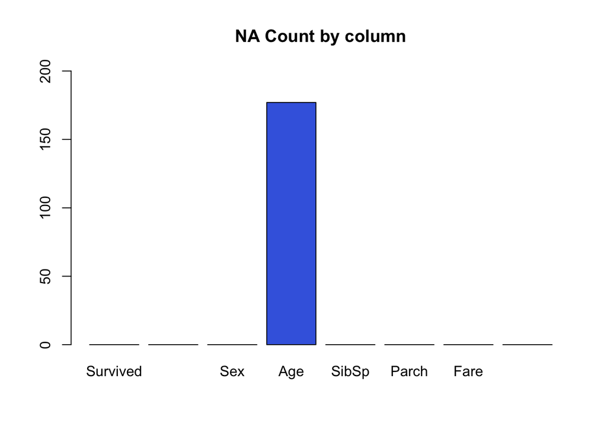

```r
Na_plot<- barplot(na_counts, main="NA Count by column",col="royalblue",ylim =c(0,200))
```

1.7. Show/plot the distribution of ages for each gender. Is the average (mean) age of Males higher? Is the median higher?

```r
#Clean out NA ages first and store as data_clean for this part
data_clean <- na.omit(data)

colSums(is.na(data_clean))
```

```
## Survived   Pclass      Sex      Age    SibSp    Parch     Fare Embarked
##        0        0        0        0        0        0        0        0
```

```r
male <- subset(data_clean, Sex == 1)
female <- subset(data_clean, Sex == 0)

#Male Average Age
print (paste("Male Average Age:",  mean(male$Age)))
```

```
## [1] "Male Average Age: 30.7266445916115"
```

```r
#Female Average Age
print (paste("Female Average Age:", mean(female$Age)))
```

```
## [1] "Female Average Age: 27.9157088122605"
```

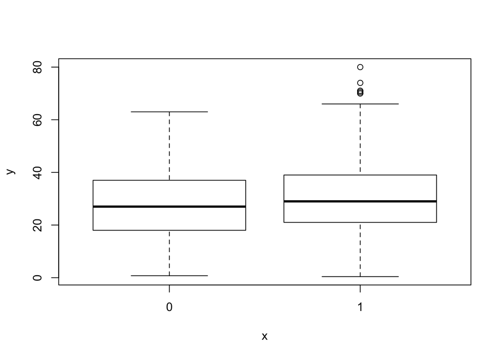

```r
#Plot distribution of ages for each gender as boxplot
plot(data_clean$Sex, data_clean$Age)
```

1 represents males, while 0 represent females.

The mean age of male is 30.72664. The mean age of female is 27.91571. So the average age of males is greater.

The median age of males is higher as shown by the box plot.

1.8. Which port of origin (embarked column) had the highest average fare? Show/plot your results.

```r
library(ggplot2)
data1 <- data[rowSums(is.na(data)) == 0,]
head(data1)
```

```
##   Survived Pclass Sex Age SibSp Parch    Fare Embarked
## 1        0      3   1  22     1     0  7.2500        S
## 2        1      1   0  38     1     0 71.2833        C
## 3        1      3   0  26     0     0  7.9250        S
## 4        1      1   0  35     1     0 53.1000        S
## 5        0      3   1  35     0     0  8.0500        S
## 7        0      1   1  54     0     0 51.8625        S
```

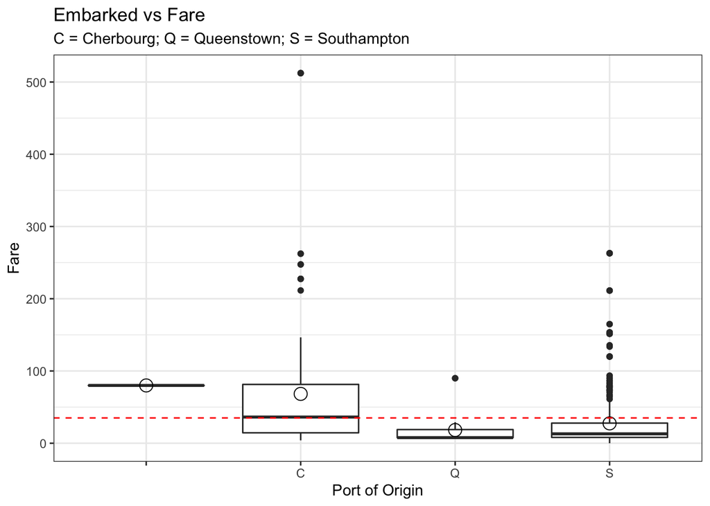

```r
ggplot(data1, aes(x = factor(Embarked), y = Fare)) +
  theme_bw() +
  geom_boxplot() +
  stat_summary(fun.y=mean, geom="point", shape=21, size=4) +
  geom_hline(aes(yintercept=35), colour='red', linetype='dashed', lwd=0.5) +
  labs(title = "Embarked vs Fare", subtitle = "C = Cherbourg; Q = Queenstown; S = Southampton", x = "Port of Origin", y = "Fare")
```

```r
#Using original data again
#Gather total unique port of origins
ports <- unique(data$Embarked)
ports
```

```
## [1] S C Q
## Levels:  C Q S
```

```r
#Average fare for C
C <- subset(data, Embarked == "C")
C_fare <- mean(C$Fare)
C_fare
```

```
## [1] 59.95414
```

```r
#Average fare for
Q <- subset(data, Embarked == "Q")
Q_fare <- mean(Q$Fare)
Q_fare
```

```
## [1] 13.27603
```

```r
#Average fare for C
S <- subset(data, Embarked == "S")
S_fare <- mean(S$Fare)
S_fare
```

```
## [1] 27.07981
```

```r
#Max fare
max_fare <- max(c(C_fare,Q_fare,S_fare))
max_fare
```

```
## [1] 59.95414
```

```r
max_port = subset(data, sum(C$Fare) == max_fare)
max_port
```

```
## [1] Survived Pclass   Sex      Age      SibSp    Parch    Fare     Embarked
## <0 rows> (or 0-length row.names)
```

```r
print(paste("The higest average fare is ", max(c(C_fare,Q_fare,S_fare))))
```

```
## [1] "The higest average fare is  59.954144047619"
```

The port of origin with the higest average fare is “C” at 59.95414.

1.9. Is there a statistically significant difference in average fares between the genders?

```r
#Using cleaned data
#Males average fare
print (paste("Males average fare", mean(male$Fare)))
```

```
## [1] "Males average fare 27.2688362030905"
```

```r
#Females average fare
print (paste("Females average fare", mean(female$Fare)))
```

```
## [1] "Females average fare 47.5827593869732"
```

```r
#t-test to
t.test(male$Fare, female$Fare)
```

```
##
##  Welch Two Sample t-test
##
## data:  male$Fare and female$Fare
## t = -4.6532, df = 428.68, p-value = 4.362e-06
## alternative hypothesis: true difference in means is not equal to 0
## 95 percent confidence interval:
##  -28.89454 -11.73331
## sample estimates:
## mean of x mean of y
##  27.26884  47.58276
```

PART 2

2.1. Load the bitly data from data.gov as a data frame.

```r
#Load JSON as a dataframe
library(jsonlite)
library(data.table)
library(stringr)
library(tidyr)
data2 <- stream_in(file("bitly_usagov_example.txt"))
```

```
## opening file input connection.
```

[output not shown]

```
## closing file input connection.
```

```r
head(data2)
```

```
##                                                                                                                                                                                                a
## 1                                                                                    Mozilla/5.0 (Windows NT 6.1; WOW64) AppleWebKit/535.11 (KHTML, like Gecko) Chrome/17.0.963.78 Safari/535.11
## 2                                                                                                                                                                         GoogleMaps/RochesterNY
## 3 Mozilla/4.0 (compatible; MSIE 8.0; Windows NT 6.1; WOW64; Trident/4.0; SLCC2; .NET CLR 2.0.50727; .NET CLR 3.5.30729; .NET CLR 3.0.30729; Media Center PC 6.0; .NET4.0C; .NET4.0E; InfoPath.3)
## 4                                                                          Mozilla/5.0 (Macintosh; Intel Mac OS X 10_6_8) AppleWebKit/534.52.7 (KHTML, like Gecko) Version/5.1.2 Safari/534.52.7
## 5                                                                                    Mozilla/5.0 (Windows NT 6.1; WOW64) AppleWebKit/535.11 (KHTML, like Gecko) Chrome/17.0.963.79 Safari/535.11
## 6                                                                                    Mozilla/5.0 (Windows NT 6.1; WOW64) AppleWebKit/535.11 (KHTML, like Gecko) Chrome/17.0.963.79 Safari/535.11
##    c nk                tz gr      g      h        l             al        hh
## 1 US  1  America/New_York MA A6qOVH wfLQtf  orofrog en-US,en;q=0.8 1.usa.gov
## 2 US  0    America/Denver UT mwszkS mwszkS    bitly           <NA>      j.mp
## 3 US  1  America/New_York DC xxr3Qb xxr3Qb    bitly          en-US 1.usa.gov
## 4 BR  0 America/Sao_Paulo 27 zCaLwp zUtuOu alelex88          pt-br 1.usa.gov
## 5 US  0  America/New_York MA 9b6kNl 9b6kNl    bitly en-US,en;q=0.8    bit.ly
## 6 US  0  America/New_York MA axNK8c axNK8c    bitly en-US,en;q=0.8    bit.ly
##                                                      r
```

[output cut: 20 more lines]

2.2. How many records are there?

```r
print(paste("Number of records: ", nrow(data2)))
```

```
## [1] "Number of records:  3560"
```

2.3. In the City column (‘cy’), how many are NA?

```r
na_counts <- sum(is.na(data2$cy))
print(paste("Number of NAs in the City column: ", na_counts))
```

```
## [1] "Number of NAs in the City column:  641"
```

2.4. How many countries are present in this data? Which country (‘c’ column) has the most records? How many does it have?

```r
#Number of countries present
print(paste("There are ", length(unique(data2$c)), " unique countries"))
```

```
## [1] "There are  72  unique countries"
```

```r
#Country with most records

print(paste("The ", names(which(table(data2$c) == max(table(data2$c)))), "  has the most number of records at ", max(table(data2$c))))
```

```
## [1] "The  US   has the most number of records at  2305"
```

2.5. How many records are from Russia?

```r
countries <- table(data2$c)

print(paste(countries[names(countries)=="RU"], " records are from Russia."))
```

```
## [1] "13  records are from Russia."
```

2.6. How many records do NOT list USA

```r
print(paste( "Including NA records, there are ",
length(data2$c)-countries[names(countries)=="US"],
" records that are not US."))
```

```
## [1] "Including NA records, there are  1255  records that are not US."
```

2.7. How many records have ‘America’ in the timezone, but Country not in US?

```r
print(paste("There are ",
sum(data2$tz %like% "America" & data2$c != "US", na.rm = TRUE),
" such records"))
```

```
## [1] "There are  143  such records"
```

2.8. How many records point to cia.gov?

```r
print(paste("There are ",
sum(data2$r %like% "cia.gov" | data2$hh %like% "cia.gov" | data2$u %like% "cia.gov", na.rm = TRUE),
" such records"))
```

```
## [1] "There are  15  such records"
```

2.9. Fill empty records with “UNKNOWN” and NA’s with “MISSING”. Create a new csv. (Submit this csv with your R Notebook.)

```r
data3 <- data2
data3[is.na(data3)] <- "MISSING"
data3[data3 == ""] <- "UNKNOWN"

#Fix ll column to character
data3$ll <- as.character(data3$ll)

write.csv(data3, file = "BetterData.csv")
```

2.10. Show the top 10 timezones (‘tz’ column) in a bar chart, with a legend, and properly labeled x,y axes and title.

```r
top_10 <- sort(table(data2$tz),decreasing=TRUE)[1:10]
print(paste("Top10 timezones", " "))
```

```
## [1] "Top10 timezones  "
```

```r
top_10
```

```
##
##    America/New_York                         America/Chicago America/Los_Angeles
##                1251                 521                 400                 382
##      America/Denver       Europe/London          Asia/Tokyo    Pacific/Honolulu
##                 191                  74                  37                  36
##       Europe/Madrid   America/Sao_Paulo
##                  35                  33
```

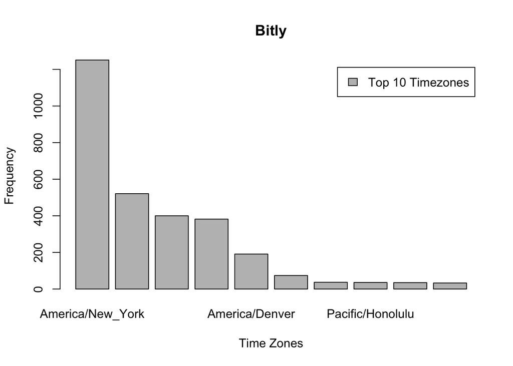

```r
barplot(top_10, main = "Bitly",legend.text = "Top 10 Timezones", xlab = "Time Zones", ylab = "Frequency")
```